# Estudio de reproducibilidad: Imágenes de desigualdad en Chile

Matias Quintana Vilches

29-10-2021

# **Resumen**

¿Cuán desigual perciben los ciudadanos que es la sociedad chilena? ¿Ha cambiado la imágen que los chilenos tienen de esa desigualdad en los últimos años? ¿ Qué factores determinan los niveles de desigualdad percibidos? El presente trabajo aborda estas preguntas utilizando datos provenientes de las encuestas del Centro de Estudios Públicos (CEP.). Los resultados muestran que los chilenos perciben mayoritariamente que viven en una sociedad desigual, que esas percepciones han variado poco a poco entre 2000 y 2013, aunque muestran una tendencia levemente más positiva para 2013 y que los principales determinantes de estas percepciones son económicos y no políticos.

Fuente: Segovia & Gamboa (2015)

# **Antecedentes**

## Medición de las percepciones de la desigualdad

¿Cuanta desigualdad perciben los ciudadanos? Existe en general, la presunción de que las personas no saben o no conocen cuáles son las diferencias de ingresos entre distintos grupos de la sociedad y por lo tanto, que tienen una estimación equivocada, habitualmente menor, de los niveles de desigualdad económica (Bartels (2008) ; Page & Jacobs (2009)). Esta presunción se basa habitualmente en argumentos y evidencia empírica asociados a los bajos niveles de conocimiento que en general, caracterizarían a la opinión pública (Converse (2000); Zaller (1992)).

Este segundo instrumento se basa en las preguntas sobre cuánto se estima que ganan las personas que trabajan en algunas ocupaciones. Con estos datos es posible estimar una brecha de ingresos entre ocupaciones de más alto y más bajo prestigio social. En una realizada en Estados Unidos utilizando este tipo de preguntas, Page y Jacobs (Page & Jacobs (2009)) muestran que las personas perciben grandes diferencias en los ingresos recibidos por diferentes ocupaciones y que estas estimaciones son bastante acertadas cuando se las compara con datos oficiales para esos mismos grupos. Page y Jacobs muestran además, que las brechas percibidas entre aquellos grupos que ganan más y aquellos grupos que ganan menos han aumentado y que esta tendencia, aunque levemente desfasada en el tiempo, se relaciona con la trayectoria de los niveles de inequidad observados en Estados Unidos (Page & Jacobs (2009)). Este parece ser entonces, un mejor instrumento para medir las percepciones de desigualdad (Kelley & Evans (1993); Kelley & Zagorski (2004) ; Page & Jacobs (2009)). Estas preguntas sin embargo, han sido implementadas solo en dos oportunidades en las encuestas del CEP, por lo que no son tan apropiadas para evaluar el cambio en las percepciones de desigualdad.

La tercera forma de medir las percepciones de desigualdad -y que utilizaremos en este trabajo- se basa en un tipo de pregunta incluido en las encuestas que le pide a los entrevistados observar unas imágenes, leer sus descripciones y señalar qué tipo de sociedad es el país (Chile) hoy. Esta medición permite evaluar las *imágenes* de desigualdad de los ciudadanos con respecto al país en el que viven. La **Figura N°1** muestra la forma en que se realiza esta pregunta.

Este instrumento de medición de percepciones fue desarrollado por Evans, Kelley y Kolosi (Evans et al. (1992)) y se ha incluido en los estudios sobre desigualdad económica del International Social Survey Programme (ISSP) desde 1992, y del CEP en Chile desde el año 2000. Aunque ha sido poco utilizada en la investigación comparada, esta pregunta tiene una serie de ventajas. Primero, no requiere de conocimiento directo por parte de los entrevistados para contestar cómo perciben los ciudadanos la sociedad en que viven. La respuesta puede ser construida utilizando distintas fuentes de información y buscan evaluar cuán igual o desigual se percibe que es la sociedad en su conjunto. De acuerdo a Evans, Kelley y Kolosi, la investigación muestra que las personas desarrollan imágenes de las sociedades en las que viven y que esas imágenes son medibles (Evans et al. (1992)).

Esta pregunta mide percepciones sin confundirlas con la evaluación que los individuos pueden tener de esa desigualdad, uno de los problemas de las preguntas que utilizan escalas de acuerdo, como se explicó anteriormente. En efecto, esta pregunta solo busca conocer cómo las personas perciben la sociedad en la que viven. Si se quisiera evaluar la valoración de los niveles de desigualdad (p.e., preguntar qué tan legítimos son), entonces se podrían incluir otras preguntas sobre por ejemplo, cómo debería ser Chile. De esta manera no se confunden distintos tipos de evaluaciones en un solo ítem (Evans et al. (1992)). Finalmente, esta pregunta es relativamente sencilla, ya que al presentar imágenes ayuda al entrevistado con respecto al texto que describe cada tipo de sociedad (Evans et al. (1992)).

La poca evidencia de la que se dispone sobre esta forma de medir percepciones de desigualdad indica que las personas son capaces de distinguir el tipo de sociedad en la que viven y que esas percepciones corresponden con el nivel de desigualdad económica medido a través de indicadores como el GINI (Evans et al. (1992)). Adicionalmente, esta pregunta ha demostrado su utilidad al evaluar percepciones de desigualdad en contextos políticos y sociales diversos, constituyendo así un instrumento válido y confiable (Cuneo (1996); Castillo et al. (2012); Evans et al. (1992)).

## Determinantes individuales de las percepciones de desigualdad

En general, la investigación asociada a los determinantes de las percepciones de desigualdad económica puede ser dividida en dos grupos. Una primera línea de investigación se concentra en el estudio de los determinantes de la legitimidad de la desigualdad económica, esto es, explica que las personas asignen a una situación de desigualdad mayor o menor legitimidad (Austen (n.d.); Blofield & Luna (2015) ; Cramer & Kaufman (2011) ; Kelley & Evans (1993)). La segunda línea de investigación se concentra en el estudio de los determinantes de cuánta desigualdad perciben las personas (Bartels (2008); Castillo et al. (2012); McCall (2013); Page & Jacobs (2009)).

Este trabajo se inscribe en la segunda línea mencionada y propone un modelo de análisis de las determinantes de las percepciones de desigualdad en Chile. Este es un tópico de primera importancia ya que, como lo ha demostrado la investigación comparada, las percepciones sobre desigualdad son determinantes de cuestiones políticamente relevantes, como los niveles de participación política y electoral (Schattschneider (1960); Solt (2008); Solt (2010)), el nivel de demanda de políticas redistributivas (Meltzer & Richard (1981)) o las preferencias de las personas entre partidos de distinta tendencia ideológica (Anderson & Singer (2008); Anderson & Beramendi (2012))

Ahora bien, ¿qué determina las percepciones sobre los niveles de desigualdad? ¿Qué factores nos permiten explicar que algunos individuos perciban mayor desigualad que otros en sus sociedades? La investigación se ha centrado en dos conjuntos de variables a nivel individual que explicarían el nivel de desigualdad percibido por las personas: aquellos asociados a factores económicos y otros relacionados con actitudes políticas.

## El impacto de los factores económicos en las percepciones de desigualdad

La investigación ha mostrado que distintos tipos de factores económicos pueden estar asociados a las percepciones de desigualdad que reportan los ciudadanos. En primer lugar, se ha indagado en torno al impacto que el estatus socioeconómico de las personas (medido habitualmente por el nivel de ingreso y el nivel educacional) pueda tener en las percepciones de desigualdad. Existen aquí dos hipótesis que van en direcciones opuestas. Por una parte, para algunos autores se debe esperar una percepción de mayor desigualdad entre quienes poseen menores niveles de ingreso. Al ser los más afectados por la desigualdad, estos grupos percibirían una mayor desigualdad económica en la sociedad, exhibirían una mayor preocupación por esos niveles de desigualdad y tendrían una evaluación más negativa de ella que grupos con mayores niveles de ingresos (Evans et al. (1992); Schattschneider (1960)).

Por otra parte, se observa que la estimación de ingresos es más exacta entre los gruposde profesiones más cercanas en la vida cotidiana a los entrevistados (Page & Jacobs (2009)) y que las percepciones de desigualdad se asocian positivamente a mayor ingreso y mayor nivel educacional (Castillo et al. (2012); Bartels (2008); McCall (2005); McCall (2013); Page & Jacobs (2009)). Esto estaría asociado a que las personas de ingresos y niveles educacionales saltos tendrían un mayor conocimiento de los niveles y evolución de la desigualdad y podrían por lo tanto, generar estimaciones más precisas (Bartels (2008); McCall (2005)). Como respuesta a estas expectativas dispares planteadas por la literatura, en este trabajo esperamos encontrar evidencia de una relación –que puede ser positiva o negativa– entre el estatus socio-económico y las percepciones de desigualdad de los entrevistados.

Cramer y Kaufman (2011) muestran que la percepción de los niveles de desigualdad en América Latina está influida de manera significativa por las percepciones económicas de los individuos. Es así como ellos encuentran que mientras más negativa sea la percepción de la situación económica actual y las expectativas a futuro, mayor será la evaluación negativa de la desigualdad (Cramer & Kaufman (2011)). Siguiendo a esta literatura, planteamos como hipótesis que las percepciones de desigualdad en Chile serán mayores entre quienes perciben la situación económica del país en forma negativa.

## El impacto de actitudes políticas en las percepciones de desigualdad

Desde otro ángulo, la investigación académica ha mostrado que existe una importante relación entre la posición política de los individuos y las percepciones que ellos tienen sobre la desigualdad. En efecto, se encuentra en forma consistente que se percibe mayor desigualdad –y se evalúa en forma negativa– entre quienes se identifican con la izquierda (Bartels (2008); McCall (2013); Page & Jacobs (2009)). En este trabajo entonces, esperamos observar una relación entre posición política y percepciones de desigualdad en Chile acorde con estos resultados.

En esta línea se inserta el único análisis detallado sobre percepciones de desigualdad en Chile (Castillo et al. (2012)). En este trabajo los autores evalúan percepciones de desigualdad utilizando tres medidas diferentes: brechas de ingresos entre profesiones, percepción general de desigualdad y percepción diagramática de desigualdad para el año 2009. Con respecto a las percepciones diagramáticas –que son las que estudiaremos aquí– los autores muestran que están positivamente relacionadas con el estatus económico subjetivo, es decir que a mayor estatus, la sociedad chilena se percibe como más desigual. También indican que no se observan, para ese año, asociaciones estadísticamente significativas con la posición política de los entrevistados. En este trabajo avanzamos en esta misma línea, ampliando el número de mediciones utilizadas para observar los determinantes de las percepciones de desigualdad en un período de más de 13 años (2000-2013), lo que no se había realizado hasta ahora.

*Fuente: Segovia, C., & Gamboa, R. (2015). Imágenes de desigualdad en Chile: El impacto de factores económicos y políticos. Papel Politico, 20(2), 481–500. https://doi.org/10.11144/Javeriana.papo20-2.idc*

# **Metodología**

## Variables

### Variable dependiente: Imágenes de desigualdad

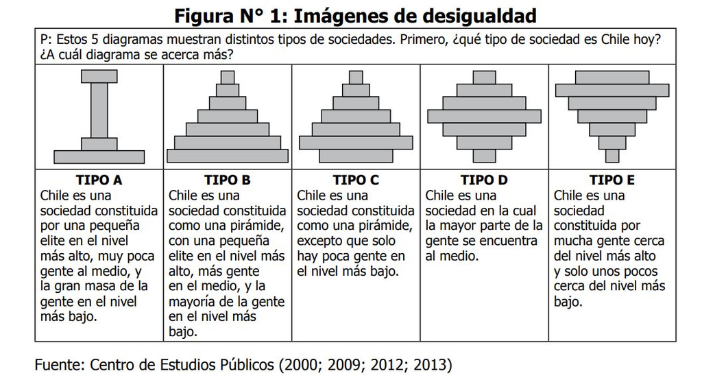

### Variables independiente: Factores económicos

### Variables independiente: Factores políticos

**Tabla 02: Tabla de información de variables**

[output not shown]

# **Análisis**

# **Bibliografía**

Anderson, C. J., & Beramendi, P. (2012). Left Parties, Poor Voters, and Electoral Participation in Advanced Industrial Societies. *Comparative Political Studies*, *45*(6), 714–746. https://doi.org/10.1177/0010414011427880

Anderson, C. J., & Singer, M. M. (2008). The Sensitive Left and the Impervious Right: Multilevel Models and the Politics of Inequality, Ideology, and Legitimacy in Europe. *Comparative Political Studies*, *41*(4-5), 564–599. https://doi.org/10.1177/0010414007313113

Austen, S. (n.d.). Norms of Inequality: Journal of Economic Issues: Vol 33, No 2. *Taylor & Francis*, *33*(2).

Bartels, L. M. (2008). *Unequal democracy. The Political Economy of the New Gilded Age*. New York: Russell Sage Foundation & Princeton University Press.

Blofield, M., & Luna, J. (2015). *PUBLIC OPINION ON INCOME INEQUALITIES IN LATIN AMERICA* (pp. 147–182). https://doi.org/10.5325/j.ctv14gp9cw.9

Castillo, J. C., Miranda, D., & Carrasco, D. (2012). Percepción de Desigualdad Económica en Chile: Medición, Diferencias y Determinantes. *Psykhe (Santiago)*, *21*(1), 99–114. https://doi.org/10.4067/S0718-22282012000100007

Converse, P. E. (2000). Assessing the Capacity of Mass Electorates. *Annual Review of Political Science*, *3*(1), 331–353. https://doi.org/10.1146/annurev.polisci.3.1.331

Cramer, B. D., & Kaufman, R. R. (2011). Views of Economic Inequality in Latin America - Brian D. Cramer, Robert R. Kaufman, 2011. *SAGE Journals*, *44*(9), 1206–1237.

Cuneo, C. (1996). International images of social inequality: A ten-country comparison. *Social Inequality in Canada*, 31–65.

Evans, M. D., Kelley, J., & Kolosi, T. (1992). Images of class: Public perceptions in Hungary and Australia. *American Sociological Review*, 461–482.

Kelley, J., & Evans, M. D. (1993). The legitimation of inequality: Occupational earnings in nine nations. *American Journal of Sociology*, *99*(1), 75–125.

Kelley, J., & Zagorski, K. (2004). Economic change and the legitimation of inequality: The transition from socialism to the free market in Central-East Europe. *Research in Social Stratification and Mobility*, *22*, 319–364.

McCall, L. (2005). Do they know and do they care? Americans’ awareness of rising inequality. *Work. Pap., Russell Sage Found*.

McCall, L. (2013). *The undeserving rich: American beliefs about inequality, opportunity, and redistribution*. Cambridge University Press.

McCall, L., & Kenworthy, L. (2009). Americans’ social policy preferences in the era of rising inequality. *Perspectives on Politics*, *7*(3), 459–484.

Meltzer, A. H., & Richard, S. F. (1981). A rational theory of the size of government. *Journal of Political Economy*, *89*(5), 914–927.

Page, B. I., & Jacobs, L. R. (2009). *Class War?* University of Chicago Press.

Schattschneider, E. E. (1960). *The Semisovereign People: A Realists View of Democracy in America, Illinois*. The Drayden Press.

Segovia, C., & Gamboa, R. (2015). Imágenes de desigualdad en Chile: El impacto de factores económicos y políticos. *Papel Politico*, *20*(2), 481–500. https://doi.org/10.11144/Javeriana.papo20-2.idc

Solt, F. (2008). Economic inequality and democratic political engagement. *American Journal of Political Science*, *52*(1), 48–60.

Solt, F. (2010). Does economic inequality depress electoral participation? Testing the Schattschneider hypothesis. *Political Behavior*, *32*(2), 285–301.

Zaller, J. R. (1992). *The nature and origins of mass opinion*. Cambridge university press.